# Lab_3

## Boostrapping Pengin Flipper Lengths

1. Get packages

```r
library(tidyverse)
library(boot)
library(nlstools)
```

2. Import data and manipulate

```r
penguins <- read_csv("~/Downloads/244/Lab_3/penguins.csv")
flip <- penguins %>%
  filter(sex == "FEMALE") %>%
  select(flipper_length)

flip_v <- flip$flipper_length
```

3. Create a function to calculate the means of the bootstrap samples

```r
mean_fun <- function(x,i) {mean (x[i])}
```

4. Bootstrap flip_v

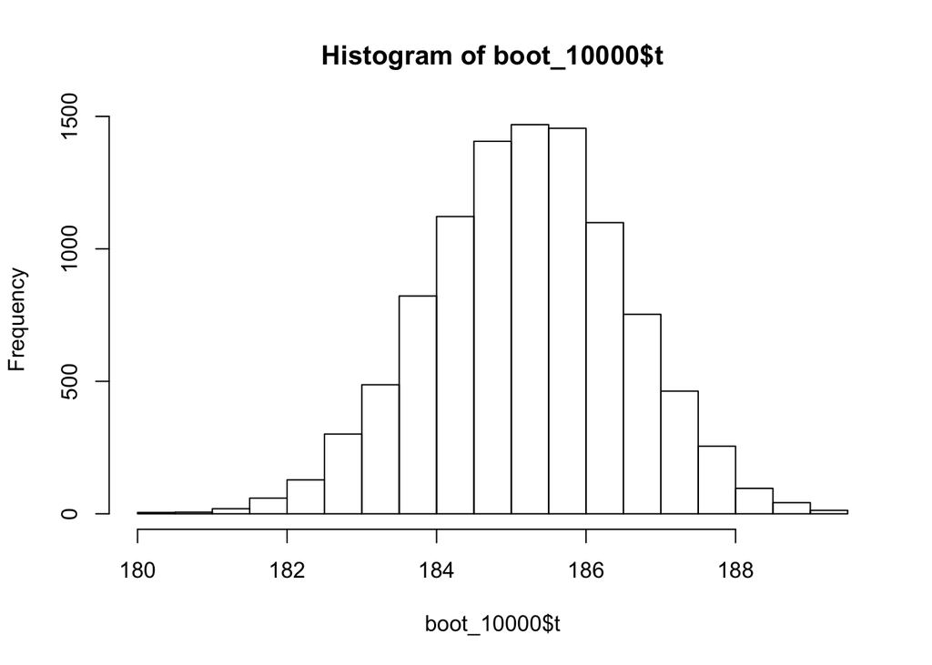

```r
boot_10000 <- boot(flip_v, mean_fun, R = 10000)
#boot_10000$t
hist(boot_10000$t)
```

5. Find the confidence interval based on the sampling distribution using function boot.ci()

```r
penguin_ci <- boot.ci(boot_10000, conf = .95, type = "perc")
penguin_ci
```

```
## BOOTSTRAP CONFIDENCE INTERVAL CALCULATIONS
## Based on 10000 bootstrap replicates
##
## CALL :
## boot.ci(boot.out = boot_10000, conf = 0.95, type = "perc")
##
## Intervals :
## Level     Percentile
## 95%   (182.6, 187.8 )
## Calculations and Intervals on Original Scale
```

## Cell Growth

1. Read Data

```r
CellGrowth <- read_csv("~/Downloads/244/Lab_3/CellGrowth.csv")
```

2. look at it

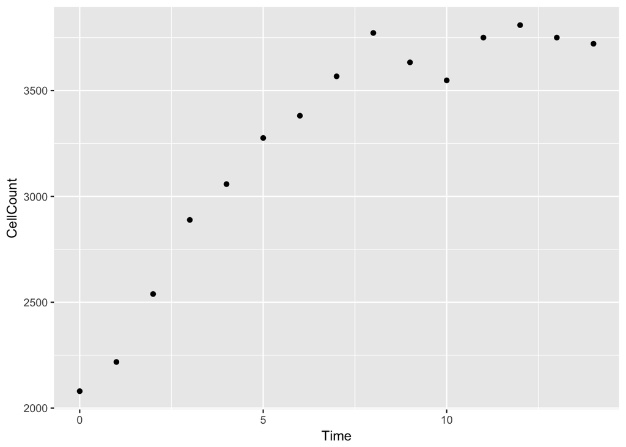

```r
ggplot(CellGrowth, aes(x = Time, y = CellCount)) +
  geom_point()
```

Ct = A / (1 + Be^-rt)

Estimate for K ~ 3700 Estimate for C0 ~ 2000 Estimate for B ~ .85

Create a linear model between the natural log of CellCount and Time for the first 5 observations (these look like they might follow exponential gorwth). The slope of that line is an estimate for the growth rate constant

```r
r_est <- lm(log(CellGrowth$CellCount[1:5]) ~ CellGrowth$Time[1:5])
r_est
```

```
##
## Call:
## lm(formula = log(CellGrowth$CellCount[1:5]) ~ CellGrowth$Time[1:5])
##
## Coefficients:
##          (Intercept)  CellGrowth$Time[1:5]
##               7.6286                0.1035
```

```r
#r starting estimate = 0.1035
```

Estimate for A ~ 3700 Estimate for B ~ .85 Estimate for r ~ 0.1035

NLS for estimating parameter values for logistic growth, starting with our estimate for A, B, and r

C = A / (1 + Be^-rt)

```r
cell_fit <- nls(CellCount ~ A / (1 + B*exp(-r*Time)),
                data = CellGrowth,
                start = list(A = 3700, B = 0.85, r = 0.1035),
                trace = TRUE
                )
```

```
## 7996304 :  3700.0000    0.8500    0.1035
## 7595140 :  3293.8084442    0.6431423    0.1437013
## 5307698 :  3197.140704    0.595545    0.215801
## 1494838 :  3436.8256143    0.7253421    0.3060712
## 88027.23 :  3802.4852184    0.9209577    0.3501814
## 87191.74 :  3806.5481869    0.9228920    0.3435714
## 87187.73 :  3805.8080711    0.9233090    0.3443107
## 87187.7 :  3805.8993927    0.9232887    0.3442454
## 87187.7 :  3805.8912348    0.9232910    0.3442515
```

```r
A <- coef(cell_fit)[1]
B <- coef(cell_fit)[2]
r <- coef(cell_fit)[3]
```

Create a time sequence (from 0 to 20 hours, and I want there to be 100). Then I’m going to plug that into my model to find the predicted cell population size

```r
time_seq <- seq(0, 20, length = 100)
time_seq
```

```
##   [1]  0.0000000  0.2020202  0.4040404  0.6060606  0.8080808  1.0101010
##   [7]  1.2121212  1.4141414  1.6161616  1.8181818  2.0202020  2.2222222
##  [13]  2.4242424  2.6262626  2.8282828  3.0303030  3.2323232  3.4343434
##  [19]  3.6363636  3.8383838  4.0404040  4.2424242  4.4444444  4.6464646
##  [25]  4.8484848  5.0505051  5.2525253  5.4545455  5.6565657  5.8585859
##  [31]  6.0606061  6.2626263  6.4646465  6.6666667  6.8686869  7.0707071
##  [37]  7.2727273  7.4747475  7.6767677  7.8787879  8.0808081  8.2828283
##  [43]  8.4848485  8.6868687  8.8888889  9.0909091  9.2929293  9.4949495
##  [49]  9.6969697  9.8989899 10.1010101 10.3030303 10.5050505 10.7070707
##  [55] 10.9090909 11.1111111 11.3131313 11.5151515 11.7171717 11.9191919
##  [61] 12.1212121 12.3232323 12.5252525 12.7272727 12.9292929 13.1313131
##  [67] 13.3333333 13.5353535 13.7373737 13.9393939 14.1414141 14.3434343
##  [73] 14.5454545 14.7474747 14.9494949 15.1515152 15.3535354 15.5555556
##  [79] 15.7575758 15.9595960 16.1616162 16.3636364 16.5656566 16.7676768
##  [85] 16.9696970 17.1717172 17.3737374 17.5757576 17.7777778 17.9797980
##  [91] 18.1818182 18.3838384 18.5858586 18.7878788 18.9898990 19.1919192
##  [97] 19.3939394 19.5959596 19.7979798 20.0000000
```

```r
cell_pred <- A/(1+B*exp(-r*time_seq))
cell_pred
```

```
##   [1] 1978.843 2044.791 2110.398 2175.509 2239.975 2303.653 2366.405
##   [8] 2428.103 2488.629 2547.874 2605.739 2662.138 2716.993 2770.242
##  [15] 2821.829 2871.713 2919.863 2966.256 3010.882 3053.737 3094.828
##  [22] 3134.168 3171.777 3207.682 3241.916 3274.515 3305.521 3334.978
##  [29] 3362.933 3389.435 3414.537 3438.290 3460.746 3481.960 3501.985
##  [36] 3520.873 3538.677 3555.448 3571.236 3586.090 3600.058 3613.187
##  [43] 3625.519 3637.100 3647.969 3658.167 3667.731 3676.698 3685.102
##  [50] 3692.976 3700.352 3707.258 3713.724 3719.776 3725.439 3730.738
##  [57] 3735.694 3740.328 3744.662 3748.714 3752.501 3756.041 3759.349
##  [64] 3762.440 3765.328 3768.026 3770.547 3772.901 3775.099 3777.152
##  [71] 3779.069 3780.859 3782.531 3784.091 3785.548 3786.908 3788.177
##  [78] 3789.362 3790.468 3791.500 3792.464 3793.363 3794.202 3794.985
##  [85] 3795.716 3796.398 3797.034 3797.628 3798.182 3798.699 3799.181
##  [92] 3799.631 3800.051 3800.443 3800.808 3801.150 3801.468 3801.765
##  [99] 3802.042 3802.300
```

```r
pred_df <- data.frame(time_seq, cell_pred)
pred_df
```

```
##       time_seq cell_pred
## 1    0.0000000  1978.843
## 2    0.2020202  2044.791
## 3    0.4040404  2110.398
## 4    0.6060606  2175.509
## 5    0.8080808  2239.975
## 6    1.0101010  2303.653
## 7    1.2121212  2366.405
## 8    1.4141414  2428.103
## 9    1.6161616  2488.629
## 10   1.8181818  2547.874
## 11   2.0202020  2605.739
## 12   2.2222222  2662.138
## 13   2.4242424  2716.993
## 14   2.6262626  2770.242
```

[output cut: 86 more lines]

Create a graph of original data + predictive model line

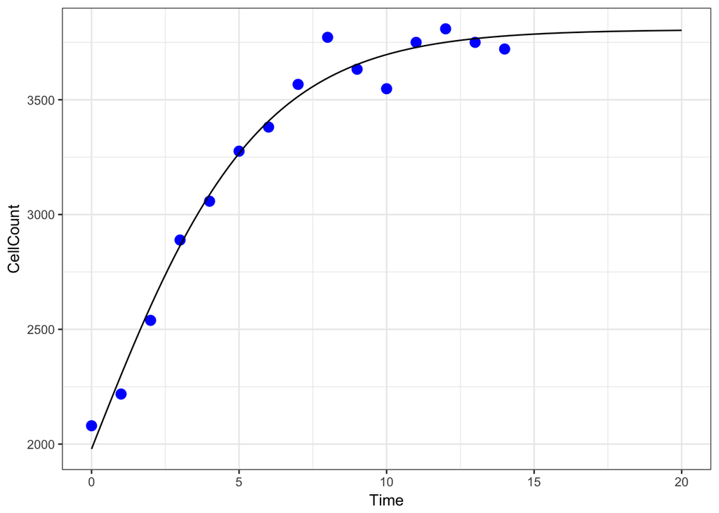

```r
ggplot(CellGrowth, aes(x=Time, y=CellCount)) +
  geom_point(color = "blue", size = 3) +
  theme_bw() +
  geom_line(data = pred_df, aes(x = time_seq, y = cell_pred))
```